# Figure 1. Root microbiota of indica and japonica.

Yong-Xin Liu

2019/2/20

## a. World map

1. Diagram of original collection sites (44 countries) of indica (red) and japonica (blue) rice.

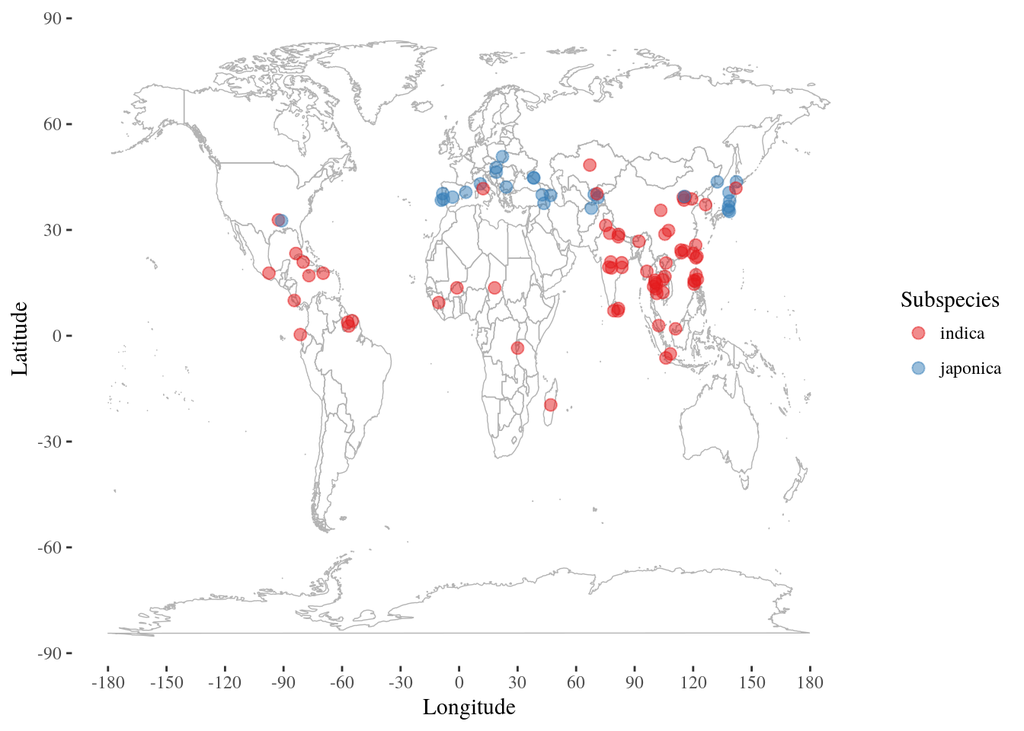

```r
library(dplyr)
library(maptools)
library(ggplot2)
library(maps)

geotable = read.table("varieties_geo.txt", header = T, sep = "\t")
worldmap = map_data("world")

fig1 = ggplot(geotable, aes(Longitude, Latitude, color = Subspecies)) +
  geom_polygon(data = worldmap, aes(x = long, y = lat, group = group, fill = NA), color = "grey70", size = 0.25)+
  geom_point(size = 2.5, alpha = 0.5)+  scale_colour_brewer(palette = "Set1") +
  scale_fill_brewer(palette = "Set1")+
  coord_cartesian()+
  scale_y_continuous(breaks = (-3:3)*30)+
  scale_x_continuous(breaks = (-6:6)*30)+
  labs(x="Longitude", y="Latitude", colour = "Subspecies" ) +
  theme_tufte()
ggsave(paste0(output_dir, "minicore-worldmap.pdf", sep=""), fig1, width = 9, height = 5)
fig1
```

## b. Experiment design

2. Diagram of the experimental design for rice field trials. The indica and japonica varieties were arranged randomly. Harvested samples for each variety were surrounded by protection plants that separated the different varieties.

This figure is manually drawn by Adobe Illustrator.

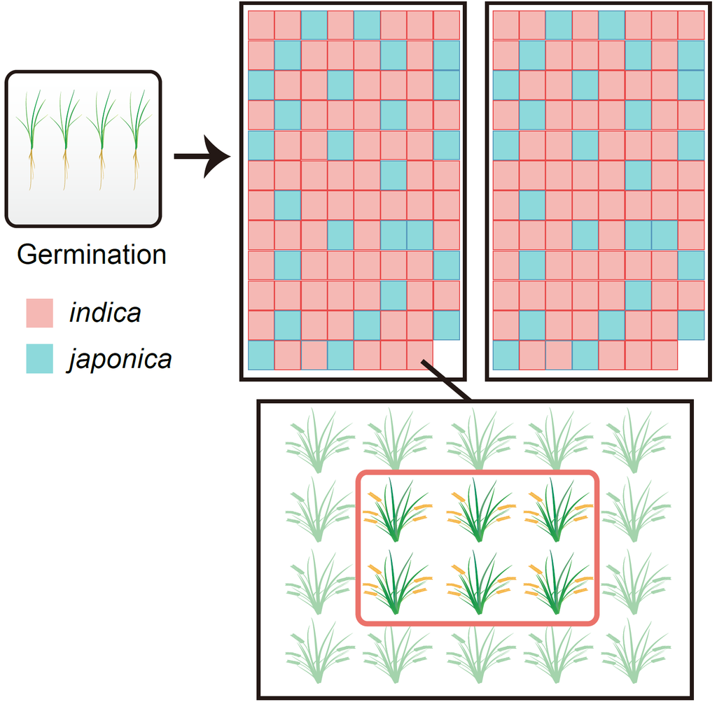

## c. PCoA filed I

3. Unconstrained Principal Coordinate Analysis with Bray-Curtis distance showing that the root microbiota of indica is separate from that of japonica in field I in the first axis (P < 0.001, PERMANOVA by Adonis). Ellipses cover 68% of the data for each rice subspecies.

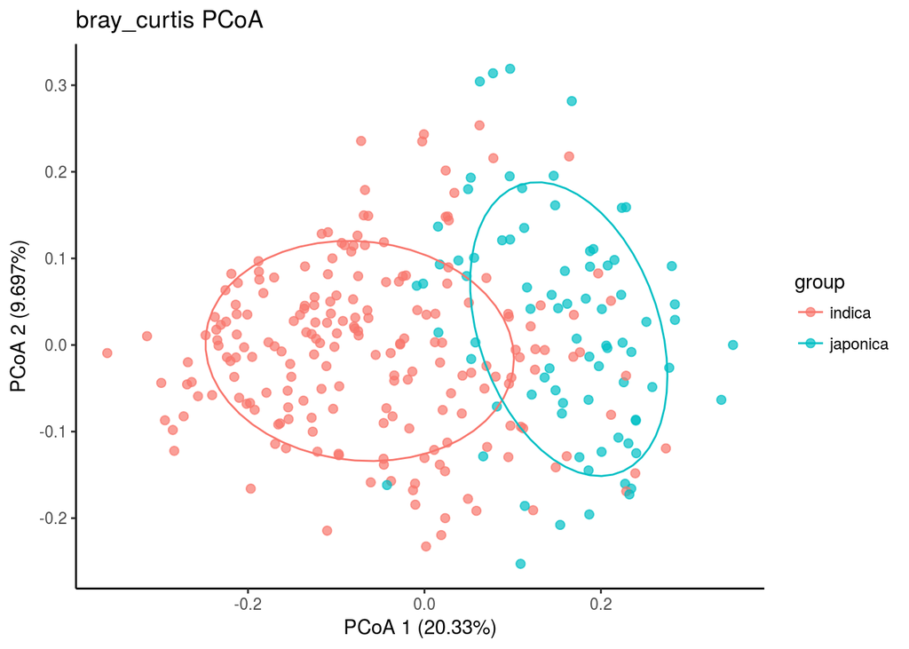

```r
design = read.table("../data/design.txt", header=T, row.names=1, sep="\t")
design$group=design$groupID

if (TRUE){
    sub_design = subset(design, group %in% c("LIND","LTEJ"))
    sub_design$group  = factor(sub_design$group, levels=c("LIND","LTEJ"))
}else{
    sub_design = design
}

# method = c("weighted_unifrac","unweighted_unifrac","bray_curtis")
# for(m in method){
m = "bray_curtis"
beta = read.table(paste(m,".txt",sep=""), header=T, row.names=1, sep="\t", comment.char="")
idx = rownames(sub_design) %in% rownames(beta)
sub_design=sub_design[idx,]
sub_beta=beta[rownames(sub_design),rownames(sub_design)]
# k is dimension, 3 is recommended; eig is eigenvalues
pcoa = cmdscale(sub_beta, k=4, eig=T)
# get coordinate string, format to dataframme
points = as.data.frame(pcoa$points)
eig = pcoa$eig
# rename group name
levels(sub_design$group)=c("indica","japonica")
points = cbind(points, sub_design$group)
colnames(points) = c("PC1", "PC2", "PC3", "PC4","group")
p = ggplot(points, aes(x=PC1, y=PC2, color=group)) + geom_point(alpha=.7, size=2) +
    labs(x=paste("PCoA 1 (", format(100 * eig[1] / sum(eig), digits=4), "%)", sep=""),
    y=paste("PCoA 2 (", format(100 * eig[2] / sum(eig), digits=4), "%)", sep=""),
    title=paste(m," PCoA",sep="")) + theme_classic()
p = p + stat_ellipse(level=0.68)
ggsave(paste0(output_dir, "beta_filedI_", m, ".pdf", sep=""), p, width = 5, height = 3)
# }
p
```

## d. PCoA filed II

4. Unconstrained Principal Coordinate Analysis with Bray-Curtis distance showing that the root microbiota of indica is separate from that of japonica in field II in the first axis (P < 0.001, PERMANOVA by Adonis).

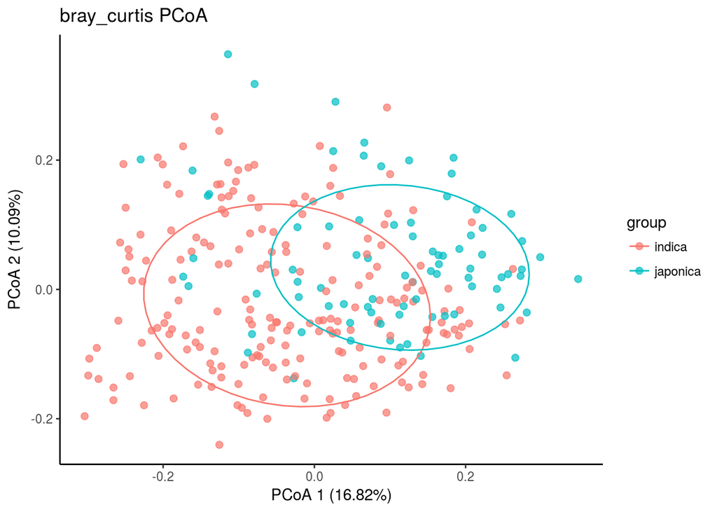

```r
design = read.table("../data/design.txt", header=T, row.names=1, sep="\t")
design$group=design$groupID

if (TRUE){
    sub_design = subset(design, group %in% c("HIND","HTEJ"))
    sub_design$group  = factor(sub_design$group, levels=c("HIND","HTEJ"))
}else{
    sub_design = design
}

# method = c("weighted_unifrac","unweighted_unifrac","bray_curtis")
# for(m in method){
m = "bray_curtis"
beta = read.table(paste(m,".txt",sep=""), header=T, row.names=1, sep="\t", comment.char="")
idx = rownames(sub_design) %in% rownames(beta)
sub_design=sub_design[idx,]
sub_beta=beta[rownames(sub_design),rownames(sub_design)]
# k is dimension, 3 is recommended; eig is eigenvalues
pcoa = cmdscale(sub_beta, k=4, eig=T)
# get coordinate string, format to dataframme
points = as.data.frame(pcoa$points)
eig = pcoa$eig
# rename group name
levels(sub_design$group)=c("indica","japonica")
points = cbind(points, sub_design$group)
colnames(points) = c("PC1", "PC2", "PC3", "PC4","group")
p = ggplot(points, aes(x=PC1, y=PC2, color=group)) + geom_point(alpha=.7, size=2) +
    labs(x=paste("PCoA 1 (", format(100 * eig[1] / sum(eig), digits=4), "%)", sep=""),
    y=paste("PCoA 2 (", format(100 * eig[2] / sum(eig), digits=4), "%)", sep=""),
    title=paste(m," PCoA",sep="")) + theme_classic()
p = p + stat_ellipse(level=0.68)
ggsave(paste0(output_dir, "beta_filedII_", m, ".pdf", sep=""), p, width = 5, height = 3)
# }
p
```

## e. Alpha diversity

5. Shannon index of the microbiota of roots from indica, japonica, and the corresponding bulk soil in two fields. The horizontal bars within boxes represent medians. The tops and bottoms of boxes represent 75th and 25th quartiles, respectively. The upper and lower whiskers extend 1.5 × the interquartile range from the upper edge and lower edge of the box, respectively.

Plotting Alpha boxlot for field I & II

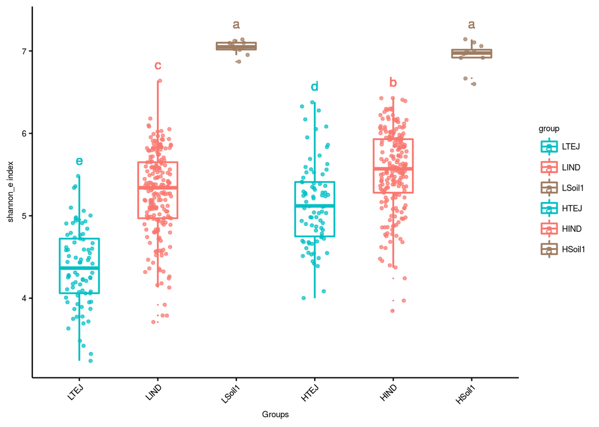

```r
# Read usearch alpha file
alpha = read.table("alpha.txt", header=T, row.names=1, sep="\t", comment.char="")

# Read design
design = read.table("../data/design.txt", header=T, row.names=1, sep="\t")
# Uniform group column as group
design$group=design$groupID

# Select by manual set group
if (TRUE){
    sub_design = subset(design, group %in% c("LTEJ","LIND","LSoil1","HTEJ","HIND","HSoil1"))
# Set group order
    sub_design$group  = factor(sub_design$group, levels=c("LTEJ","LIND","LSoil1","HTEJ","HIND","HSoil1"))
}else{
    sub_design = design
}

# Cross filter
idx = rownames(sub_design) %in% rownames(alpha)
sub_design=sub_design[idx,]
sub_alpha=alpha[rownames(sub_design),]

# Add design to alpha
index = cbind(sub_alpha, sub_design)


# sub_function. loop for statiscs and plot for each index
# method = c("chao1","richness","shannon_e")
# for(m in method){
m = "shannon_e"
model = aov(index[[m]] ~ group, data=index)
Tukey_HSD = TukeyHSD(model, ordered = TRUE, conf.level = 0.95)
Tukey_HSD_table = as.data.frame(Tukey_HSD$group)
write.table(paste(m, "\n\t", sep=""), file=paste(output_dir, "alpha_",m,".txt",sep=""),append = F, quote = F, eol = "", row.names = F, col.names = F)
suppressWarnings(write.table(Tukey_HSD_table, file=paste("alpha_",m,".txt",sep=""), append = T, quote = F, sep="\t", eol = "\n", na = "NA", dec = ".", row.names = T, col.names = T))

# LSD test for stat label
out = LSD.test(model,"group", p.adj="none") # alternative fdr
stat = out$groups
index$stat=stat[as.character(index$group),]$groups
max=max(index[,c(m)])
min=min(index[,c(m)])
x = index[,c("group",m)]
y = x %>% group_by(group) %>% summarise_(Max=paste('max(',m,')',sep=""))
y=as.data.frame(y)
rownames(y)=y$group
index$y=y[as.character(index$group),]$Max + (max-min)*0.05

p = ggplot(index, aes(x=group, y=index[[m]], color=group)) +
    geom_boxplot(alpha=1, outlier.size=0, size=0.7, width=0.5, fill="transparent") +
    labs(x="Groups", y=paste(m, "index")) + theme_classic() + main_theme +
    geom_text(data=index, aes(x=group, y=y, color=group, label= stat)) +
    geom_jitter( position=position_jitter(0.17), size=1, alpha=0.7)
if (length(unique(sub_design$group))>3){
    p=p+theme(axis.text.x=element_text(angle=45,vjust=1, hjust=1))
}
color = c("#00BFC4", "#F9766E", "#9E7C61", "#00BFC4", "#F9766E", "#9E7C61")
p = p + scale_color_manual(values = color)
ggsave(paste(output_dir,"alpha_", m, ".pdf", sep=""), p, width = 5, height = 3)
p
```

```r
# }
```

## f. taxonomy composition

6. Phylum-level distribution of the indica and japonica root microbiota in two fields. The number of biological replicates in this figure is as follows: in field I, indica (n = 201), japonica (n = 80); in field II, indica (n = 201), japonica (n = 81).

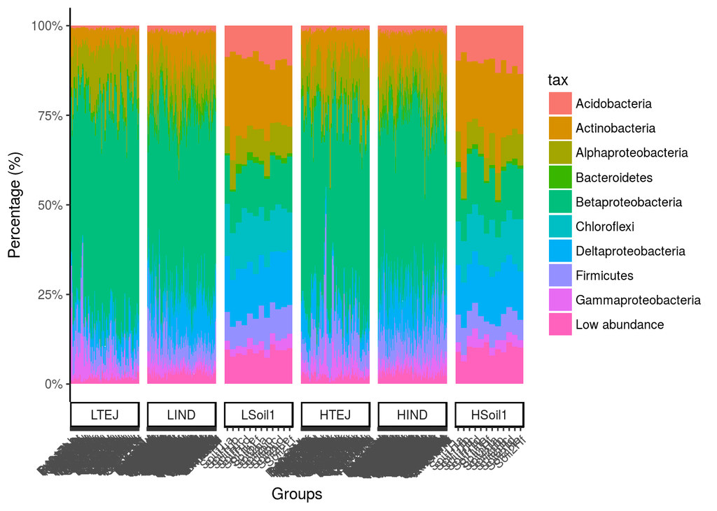

```r
site="https://mirrors.tuna.tsinghua.edu.cn/CRAN"
# Delect dependency, install or loading packages
package_list = c("reshape2","ggplot2","vegan")
# Check each packages is available
for(p in package_list){
    if(!suppressWarnings(suppressMessages(require(p, character.only = TRUE, quietly = TRUE, warn.conflicts = FALSE)))){
        install.packages(p, repos=site)
        suppressWarnings(suppressMessages(library(p, character.only = TRUE, quietly = TRUE, warn.conflicts = FALSE)))
  }
}

# Read input file
# Design file
design = read.table("../data/design.txt", header=T, row.names=1, sep="\t")
# Group by
design$group = design$groupID

# Select by manual set group
if (TRUE){
    sub_design = subset(design, group %in% c("LTEJ","LIND","LSoil1","HTEJ","HIND","HSoil1"))
# Set group order
    sub_design$group  = factor(sub_design$group, levels=c("LTEJ","LIND","LSoil1","HTEJ","HIND","HSoil1"))
}else{
    sub_design = design[,c("SampleID","group")]
}

# Draw figure in phylum level and Proteobacteria class
m = "pc"
# read usearch taxonomy summary file
tax_sample = read.table(paste("../data/sum_", m, ".txt", sep=""), header=T, row.names=1, sep="\t", comment.char="")

# Decreased sort by abundance
mean_sort = tax_sample[(order(-rowSums(tax_sample))), ]
mean_sort = as.data.frame(mean_sort)
# Filter Top 9 , and other group into Low abundance
other = colSums(mean_sort[10:dim(mean_sort)[1], ])
mean_sort = mean_sort[1:(10 - 1), ]
mean_sort = rbind(mean_sort,other)
rownames(mean_sort)[10] = c("Low abundance")
# Double check
# colSums(mean_sort)

# Cross filter metadata and features table
idx = rownames(sub_design) %in% colnames(mean_sort)
sub_design=sub_design[idx,]
mean_sort = mean_sort[,rownames(sub_design)]


# step 1. Stackplot for each samples
merge_tax=mean_sort
write.table("\t", file=paste("tax_pc_", m, "_sample.txt",sep=""),append = F, quote = F, eol = "", row.names = F, col.names = F)
suppressWarnings(write.table(merge_tax, file=paste("tax_pc_", m, "_sample.txt",sep=""), append = T, quote = F, sep="\t", eol = "\n", na = "NA", dec = ".", row.names = T, col.names = T))

# Select group information
sampFile = data.frame(sample=row.names(sub_design), group=sub_design$group,row.names = row.names(sub_design))

# Add taxonomy
mean_sort$tax = rownames(mean_sort)
data_all = as.data.frame(melt(mean_sort, id.vars=c("tax")))
# Set taxonomy order by abundance, default by alphabet
if (FALSE){
    data_all$tax  = factor(data_all$tax, levels=rownames(mean_sort))
}
data_all = merge(data_all, sampFile, by.x="variable", by.y = "sample")

p = ggplot(data_all, aes(x=variable, y = value, fill = tax )) +
    geom_bar(stat = "identity",position="fill", width=1)+
    scale_y_continuous(labels = scales::percent) +
    facet_grid( ~ group, scales = "free_x", switch = "x") +  theme(strip.background = element_blank())+
    theme(axis.ticks.x = element_blank(), axis.text.x = element_blank())+
    xlab("Groups")+ylab("Percentage (%)")+ theme_classic()+theme(axis.text.x=element_text(angle=45,vjust=1, hjust=1))
p
```

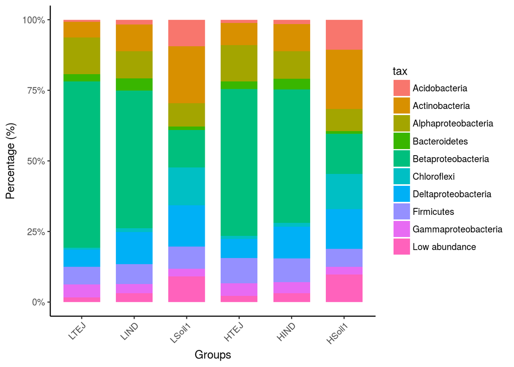

```r
# Step 2. Group average stackplot

# Calculate average relative abundance for each group
mat_t = t(merge_tax)
mat_t2 = merge(sampFile, mat_t, by="row.names")
mat_t2 = mat_t2[,c(-1,-2)]
mat_mean = aggregate(mat_t2[,-1], by=mat_t2[1], FUN=mean) # mean
mat_mean_final = do.call(rbind, mat_mean)[-1,]
geno = mat_mean$group
colnames(mat_mean_final) = geno

mean_sort=as.data.frame(mat_mean_final)
write.table("\t", file=paste("tax_pc_", m, "_group.txt",sep=""),append = F, quote = F, eol = "", row.names = F, col.names = F)
suppressWarnings(write.table(merge_tax, file=paste("tax_pc_", m, "_group.txt",sep=""), append = T, quote = F, sep="\t", eol = "\n", na = "NA", dec = ".", row.names = T, col.names = T))

# data melt for ggplot2
mean_sort$tax = rownames(mean_sort)
data_all = as.data.frame(melt(mean_sort, id.vars=c("tax")))
# Set taxonomy order by abundance, default by alphabet
if (FALSE){
    data_all$tax  = factor(data_all$tax, levels=rownames(mean_sort))
}

p = ggplot(data_all, aes(x=variable, y = value, fill = tax )) +
  geom_bar(stat = "identity",position="fill", width=0.7)+
  scale_y_continuous(labels = scales::percent) +
  xlab("Groups")+ylab("Percentage (%)")+ theme_classic()
if (length(unique(data_all$variable))>3){
    p=p+theme(axis.text.x=element_text(angle=45,vjust=1, hjust=1))
}
ggsave(paste0(output_dir, "tax_pc_", m, "_group.pdf", sep=""), p, width = 5, height = 3)
p
```